# Лабораторная работа №7

Beamer-презентации в LaTeX

Усман Траоре

Российский университет дружбы народов, Москва, Россия

04 декабря 2025

# Цель работы

## Основная цель

- освоить создание презентаций в классе **beamer**;
- научиться устанавливать и подключать пакеты в TeX Live;
- изучить приёмы поэтапного раскрытия содержимого слайдов с помощью `\pause` и `\uncover`.

# Установка и первый запуск Beamer

## Ошибка при первой компиляции

- первая компиляция файла `presentation-1.tex`;
- ошибка: не найден файл `beamer.cls`;
- документ не собирается, компиляция прерывается.

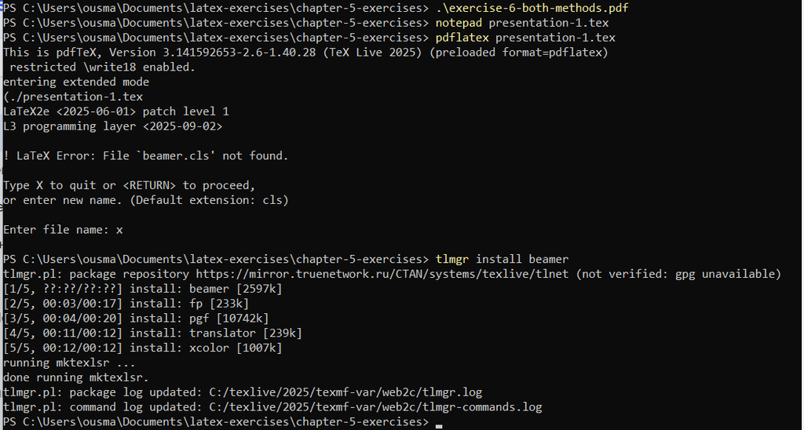

Ошибка: файл beamer.cls не найден

## Установка пакета beamer

- установка `beamer` и зависимостей через менеджер пакетов TeX Live;
- обновление файловых баз;
- проверка доступности `beamer.cls`.

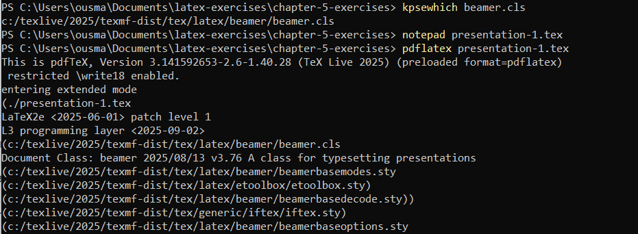

Установка пакета beamer

## Успешная компиляция первой презентации

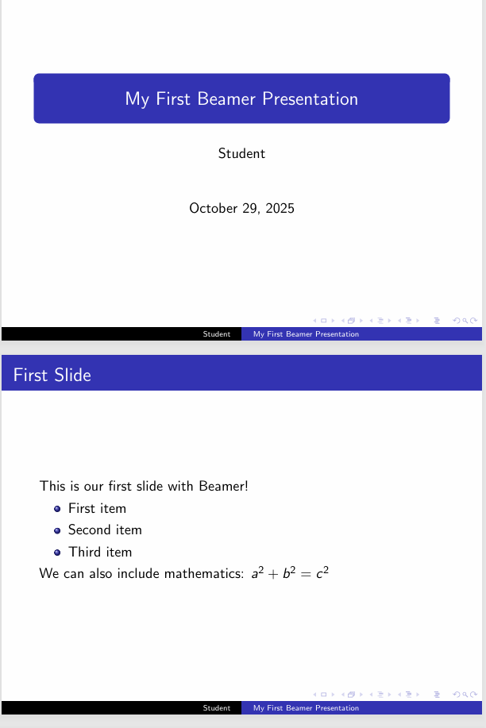

Примеры первых слайдов

# Команда `pause`

## Пошаговое появление текста

- файл `presentation-2.tex` демонстрирует работу `\pause`;
- первая строка текста видна сразу;
- последующие строки появляются после паузы.

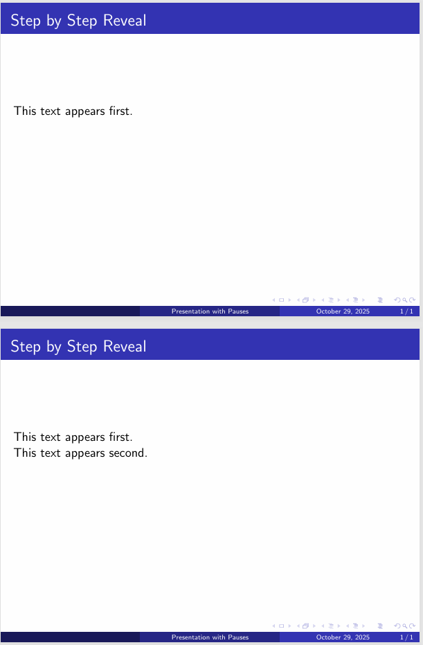

Пример работы pause

## Пошаговое раскрытие списка

- элементы списка выводятся по одному;
- удобно для постепенного объяснения материала;
- после списка может появляться дополнительный текст.

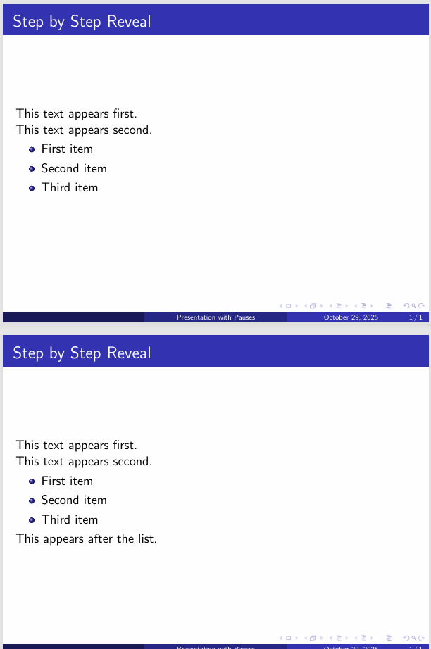

Пошаговый список

## Паузы в блоках

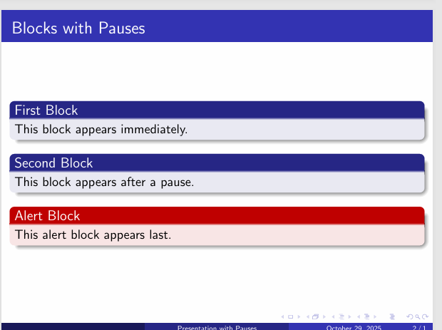

Блоки с паузами

# Команда `uncover`

## Uncover в формулах

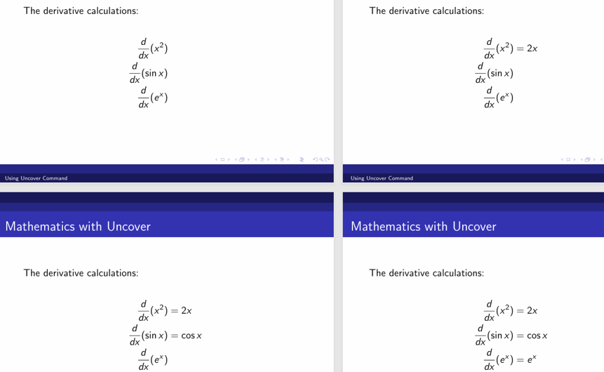

Uncover в формулах

## Uncover в списках

- каждый пункт списка видим с определённого шага показа;
- можно добавлять итоговую строку только на последнем кадре;
- обеспечивается гибкий контроль видимости элементов.

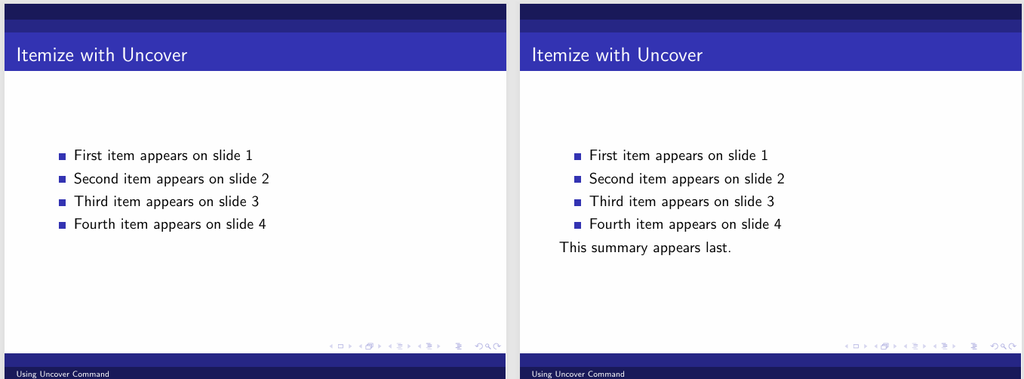

Uncover в списке

# Итоговая презентация

## Файл `exercise-7-complete.tex`

- объединяет все изученные приёмы:
  - структуру разделов и оглавление,
  - разные типы блоков,
  - команды `\pause` и `\uncover`,
  - математическое содержимое;
- использует другую цветовую тему оформления.

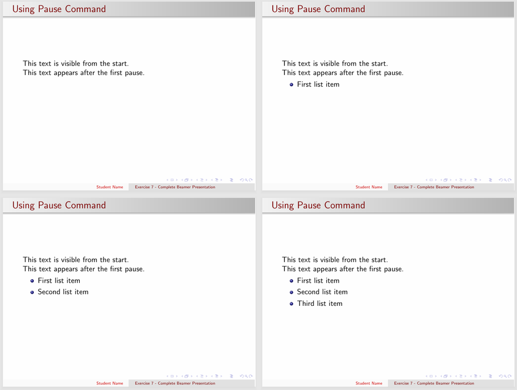

Примеры слайдов итоговой презентации

## Математическое содержимое

- вывод квадратной формулы;
- примеры производных и интеграла;
- результаты формул также могут раскрываться по шагам.

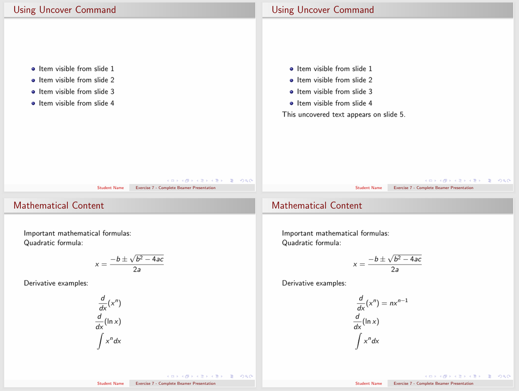

Математический слайд

# Выводы

## Основные результаты

- освоено создание презентаций в классе **beamer**;
- отработана установка и подключение пакетов в TeX Live;
- изучены приёмы покадрового вывода с помощью `\pause` и `\uncover`;
- собрана итоговая презентация, демонстрирующая ключевые возможности Beamer.